DPLevitin · Cap. 8

Diseño algorítmico

# Resolver una vez. Recordar siempre.

La programación dinámica convierte recursiones con subproblemas repetidos en tablas que crecen de lo pequeño a lo grande y conservan las decisiones óptimas.

**4**familias del capítulo

**7**laboratorios visuales

**1×**cada subproblema

Tabla ascendente`F[i] = óptimo(subproblemas)`

*0**5**5**7**15**17*

La última celda contiene el valor; el retroceso revela la solución.

01 · Fundamento

## De recurrencia a tabla

Dos propiedades abren la puerta: subproblemas superpuestos y estructura óptima.

1 · Definir

### Estado

Describe exactamente qué significa cada celda: por ejemplo, F(i) es el mejor valor usando las primeras i monedas.

2 · Relacionar

### Recurrencia

Expresa una solución mediante estados menores y verifica el principio de optimalidad.

3 · Ordenar

### Evaluación

Calcula bottom-up o usa una función de memoria top-down. Cada estado se resuelve una sola vez.

### Fibonacci como microscopio

n

Recursión ingenua**67**llamadas

VS

Programación dinámica**7**sumas

F(n) = F(n-1) + F(n-2) · base: F(0)=0, F(1)=1

02 · Elección local conectada

## Fila de monedas

Para la última moneda solo hay dos opciones: tomarla y saltar su vecina, o no tomarla.

### Simulador

Valores

F(i)=max(cᵢ+F(i-2), F(i-1))

### Valores y tabla F

Tomar**—**

VS

Omitir**—**

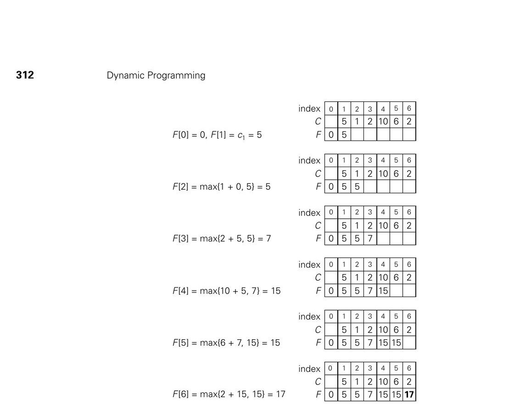

Figura 8.1: la tabla para 5, 1, 2, 10, 6, 2 produce un óptimo de 17.

03 · Minimización

## Dar cambio con menos monedas

Para cada monto, prueba la última moneda posible y conserva el mejor subresultado.

### Cambio mínimo

DenominacionesMonto

F(n)=1+min F(n-dⱼ), para dⱼ≤n

| Monto | Mejor moneda | Mínimo |
| --- | --- | --- |

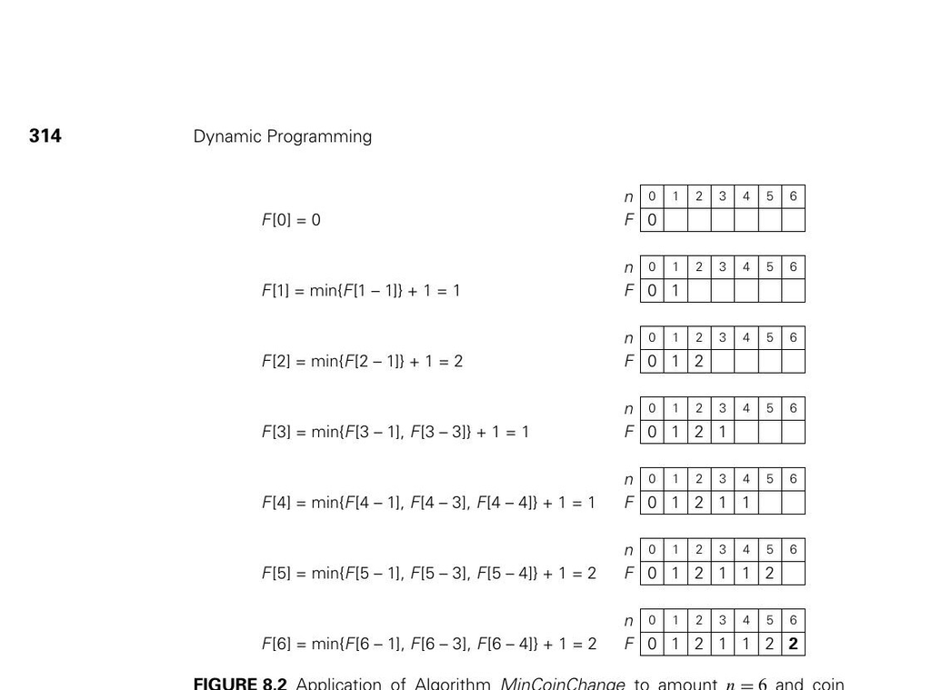

Figura 8.2: monto 6 con denominaciones 1, 3 y 4 requiere dos monedas.

04 · Tabla bidimensional

## El robot recolector

El robot solo avanza a la derecha o hacia abajo. Cada celda hereda el máximo de arriba o izquierda y suma su moneda.

### Diseña el tablero

Haz clic en una celda para poner o quitar una moneda.

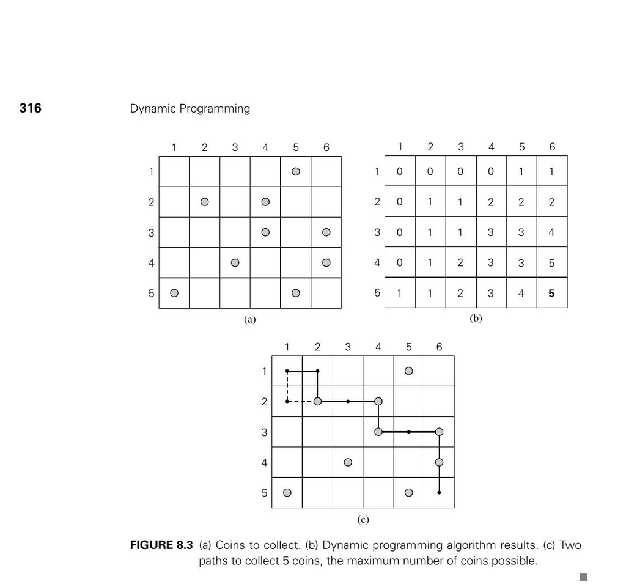

Figura 8.3: tablero, tabla dinámica y dos caminos óptimos.

05 · Funciones de memoria

## Mochila 0/1

Cada estado combina cuántos objetos se consideran y cuánta capacidad queda disponible.

### Instancia del libro

PesosValoresCapacidad

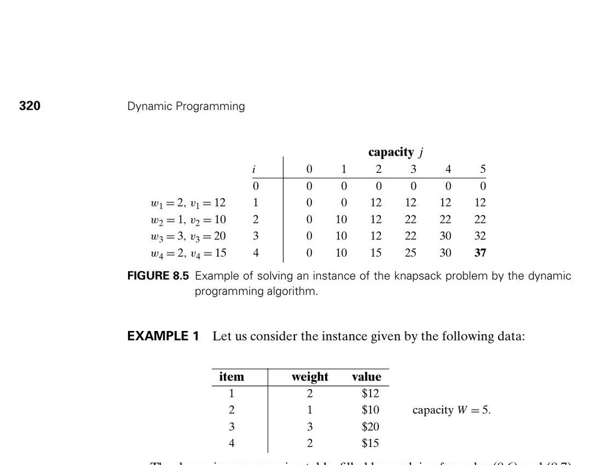

Figura 8.5: tabla de valores óptimos para la mochila de capacidad 5.

06 · Coste esperado

## Árbol de búsqueda óptimo

Las claves frecuentes deben quedar cerca de la raíz. La tabla compara todas las raíces posibles de cada intervalo.

### Constructor OBST

ClavesProbabilidades

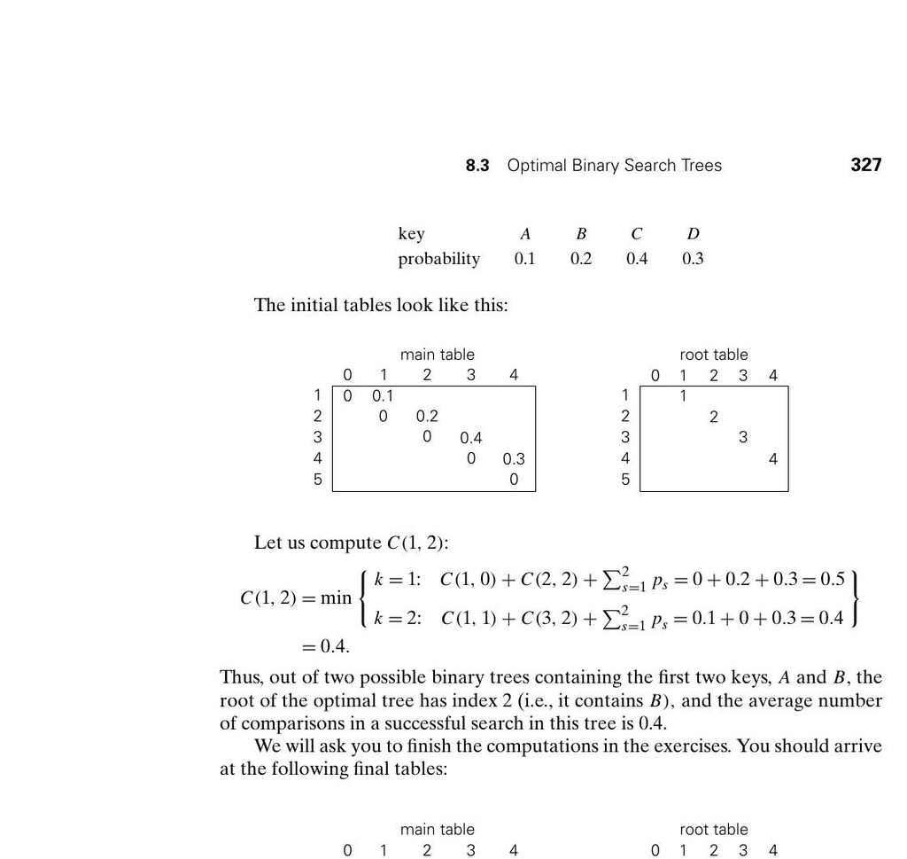

Ejemplo de las tablas de coste y raíz.

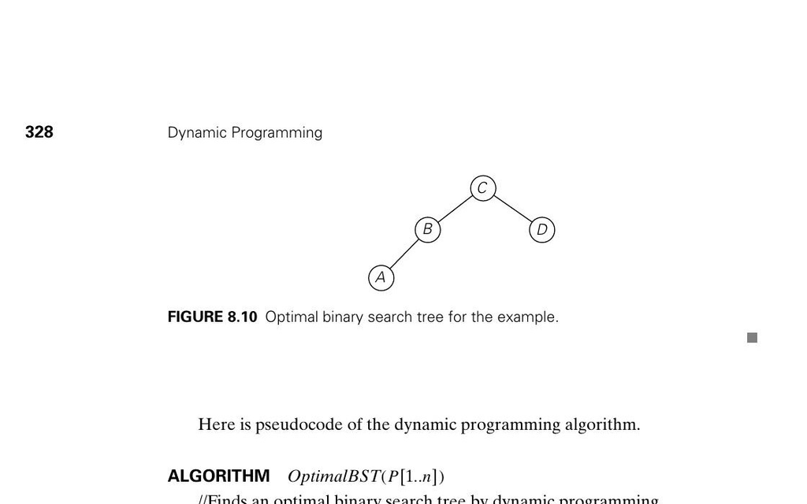

Figura 8.10: C es la raíz; B y D son hijos, y A desciende de B.

07 · Grafos

## Warshall y Floyd

La misma idea matricial responde dos preguntas: ¿existe camino? y ¿cuál es su distancia mínima?

### Cierre transitivo

En el paso k permitimos que el vértice k sea intermedio.

actualizadoconservado

Rᵏ[i,j] = Rᵏ⁻¹[i,j] ∨ (Rᵏ⁻¹[i,k] ∧ Rᵏ⁻¹[k,j])

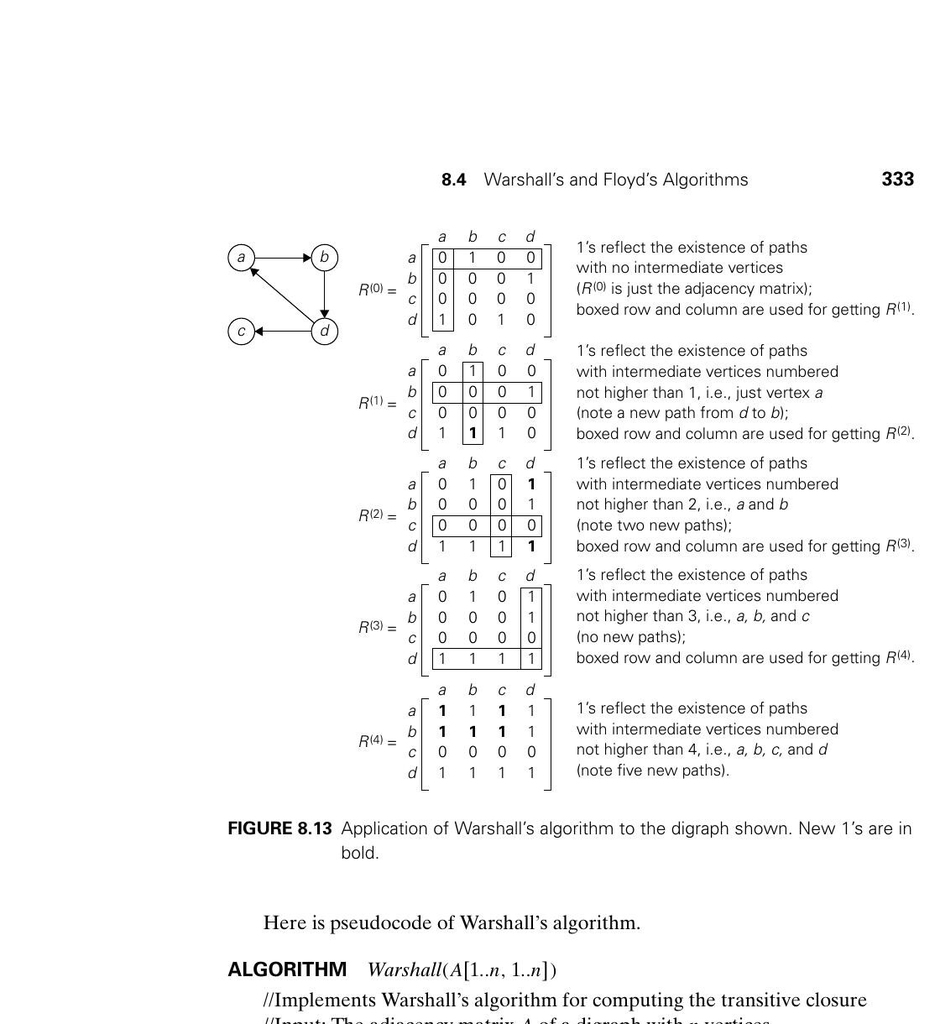

Figura 8.13: cierre transitivo, matriz por matriz.

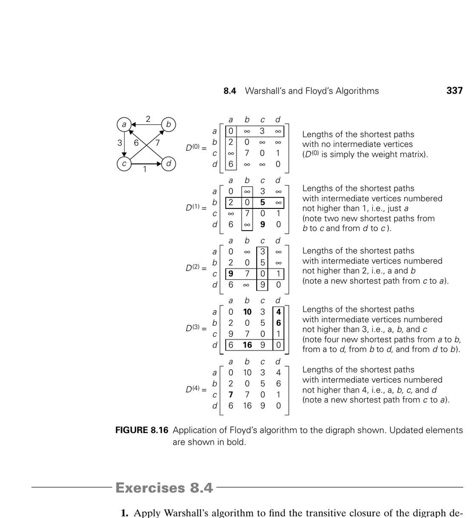

Figura 8.16: distancias mínimas con vértices intermedios crecientes.

08 · Autoevaluación

## Reto de programación dinámica

Contenido elaborado a partir de Anany Levitin, *Introduction to the Design & Analysis of Algorithms*, capítulo 8, “Dynamic Programming”. Las figuras proceden del PDF proporcionado por el usuario y se incluyen con finalidad educativa.